# Lecture 1 Time Series and Forecasting

## Regression Model 1: Time trend

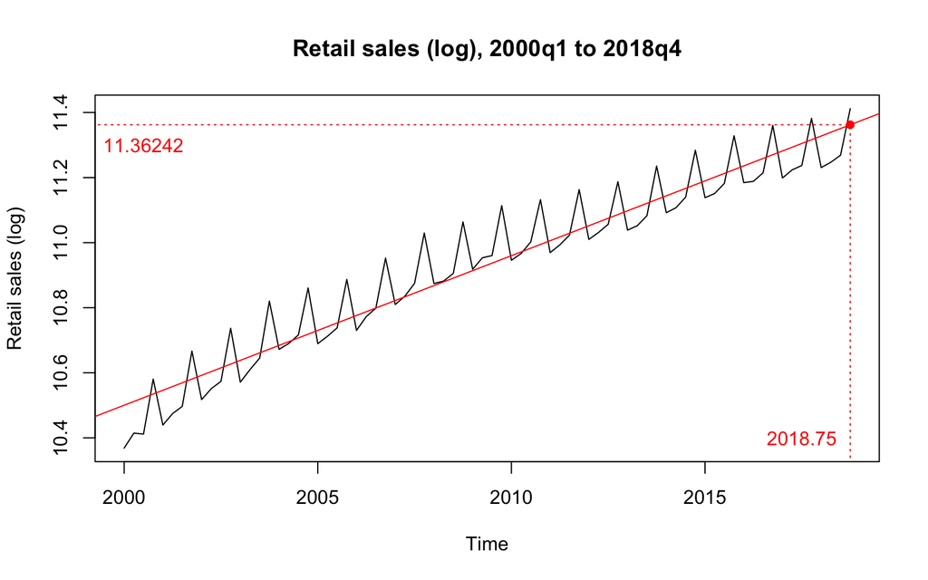

## ${\color{Apricot}{\textsf{predict}}}$ : fitted values

```r
eq1 <- lm(Y~Time_t)
EY_tr_t <- predict(eq1)
print(EY_tr_t)
```

```
       1        2        3        4        5
10.50021 10.51170 10.52320 10.53470 10.54619
       6        7        8        9       10
10.55769 10.56918 10.58068 10.59218 10.60367
      11       12       13       14       15
10.61517 10.62667 10.63816 10.64966 10.66115
      16       17       18       19       20
10.67265 10.68415 10.69564 10.70714 10.71863
      21       22       23       24       25
10.73013 10.74163 10.75312 10.76462 10.77612
      26       27       28       29       30
10.78761 10.79911 10.81060 10.82210 10.83360
      31       32       33       34       35
10.84509 10.85659 10.86808 10.87958 10.89108
      36       37       38       39       40
10.90257 10.91407 10.92557 10.93706 10.94856
      41       42       43       44       45
10.96005 10.97155 10.98305 10.99454 11.00604
      46       47       48       49       50
11.01753 11.02903 11.04053 11.05202 11.06352
      51       52       53       54       55
11.07502 11.08651 11.09801 11.10950 11.12100
      56       57       58       59       60
11.13250 11.14399 11.15549 11.16699 11.17848
      61       62       63       64       65
11.18998 11.20147 11.21297 11.22447 11.23596
      66       67       68       69       70
11.24746 11.25895 11.27045 11.28195 11.29344
      71       72       73       74       75
11.30494 11.31644 11.32793 11.33943 11.35092
      76
11.36242
```

## ${\color{Apricot}{\textsf{predict}}}$ : fitted values

```r
eq1 <- lm(Y~Time_t)
EY_tr_t <- ts(predict(eq1), start=c(2000,1),
              end=c(2018,4), frequency=4)
print(EY_tr_t)
```

```
         Qtr1     Qtr2     Qtr3     Qtr4
2000 10.50021 10.51170 10.52320 10.53470
2001 10.54619 10.55769 10.56918 10.58068
2002 10.59218 10.60367 10.61517 10.62667
2003 10.63816 10.64966 10.66115 10.67265
2004 10.68415 10.69564 10.70714 10.71863
2005 10.73013 10.74163 10.75312 10.76462
2006 10.77612 10.78761 10.79911 10.81060
2007 10.82210 10.83360 10.84509 10.85659
2008 10.86808 10.87958 10.89108 10.90257
2009 10.91407 10.92557 10.93706 10.94856
2010 10.96005 10.97155 10.98305 10.99454
2011 11.00604 11.01753 11.02903 11.04053
2012 11.05202 11.06352 11.07502 11.08651
2013 11.09801 11.10950 11.12100 11.13250
2014 11.14399 11.15549 11.16699 11.17848
2015 11.18998 11.20147 11.21297 11.22447
2016 11.23596 11.24746 11.25895 11.27045
2017 11.28195 11.29344 11.30494 11.31644
2018 11.32793 11.33943 11.35092 11.36242
```

## ${\color{Apricot}{\textsf{predict}}}$ : fitted values

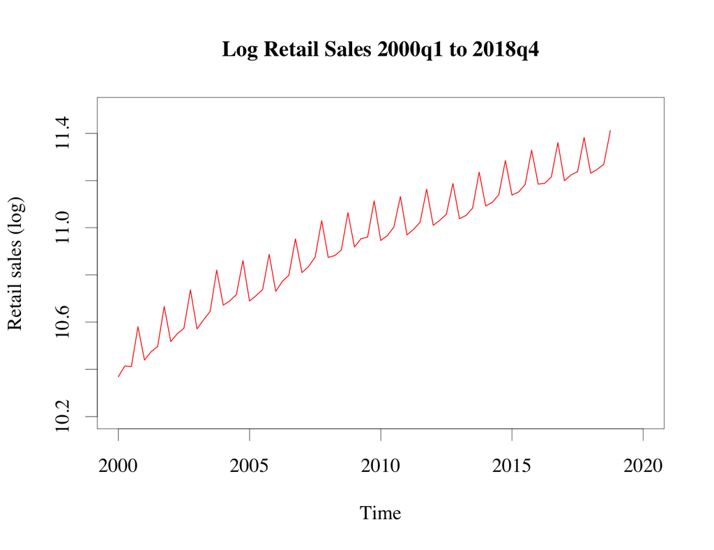

## ${\color{Apricot}{\textsf{predict}}}$ : fitted values

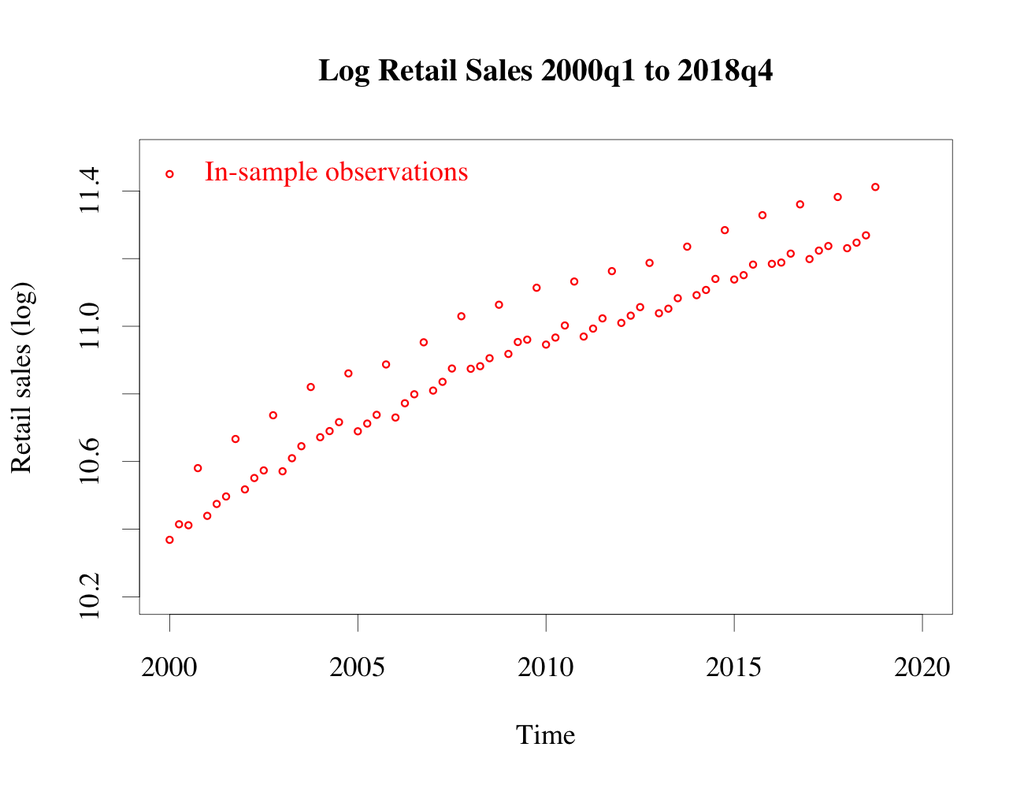

## ${\color{Apricot}{\textsf{predict}}}$ : fitted values

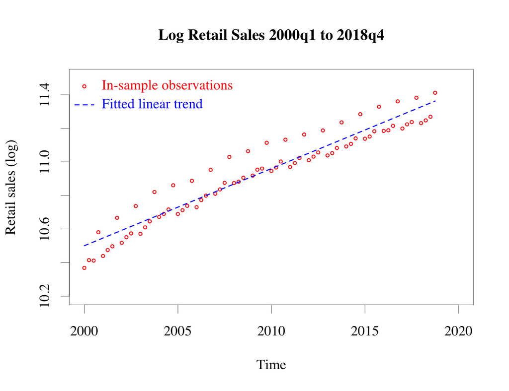

## ${\color{Apricot}{\textsf{predict}}}$ : forecast through 2019

```r
eq1 <- lm(Y~Time_t)
Time_2019 <- c(2019,2019.25,2019.5,2019.75)

# Convert to dataframe
X_2019 <- data.frame(Time_t=Time_2019)
```

## ${\color{Apricot}{\textsf{predict}}}$ : forecast through 2019

```r
eq1 <- lm(Y~Time_t)
Time_2019 <- c(2019,2019.25,2019.5,2019.75)

# Convert to dataframe
X_2019 <- data.frame(Time_t=Time_2019)
```

$$\color{magenta}{\huge{\nwarrow}}$$

$$\color{magenta}{\huge{\downarrow}}$$

$$\color{magenta}{\textsf{Time_t} : \text{name of}}$$

$$\color{magenta}{ \text{predictor in equation}}$$

## ${\color{Apricot}{\textsf{predict}}}$ : forecast through 2019

```r
eq1 <- lm(Y~Time_t)
Time_2019 <- c(2019,2019.25,2019.5,2019.75)

# Convert to dataframe
X_2019 <- data.frame(Time_t=Time_2019)
```

$$\color{magenta}{\huge{\updownarrow}}$$

$$\color{magenta}{\text{Values at which}}$$

$$\color{magenta}{\text{to predict}}$$

## ${\color{Apricot}{\textsf{predict}}}$ : forecast through 2019

```r
eq1 <- lm(Y~Time_t)
Time_2019 <- c(2019,2019.25,2019.5,2019.75)

# Convert to dataframe
X_2019 <- data.frame(Time_t=Time_2019)

# Forecast 2019 using eq1
EY_tr_2019 <- predict(eq1, newdata=X_2019)
print(EY_tr_2019)
```

```
       1        2        3        4
11.37392 11.38541 11.39691 11.40840
```

## ${\color{Apricot}{\textsf{predict}}}$ : forecast through 2019

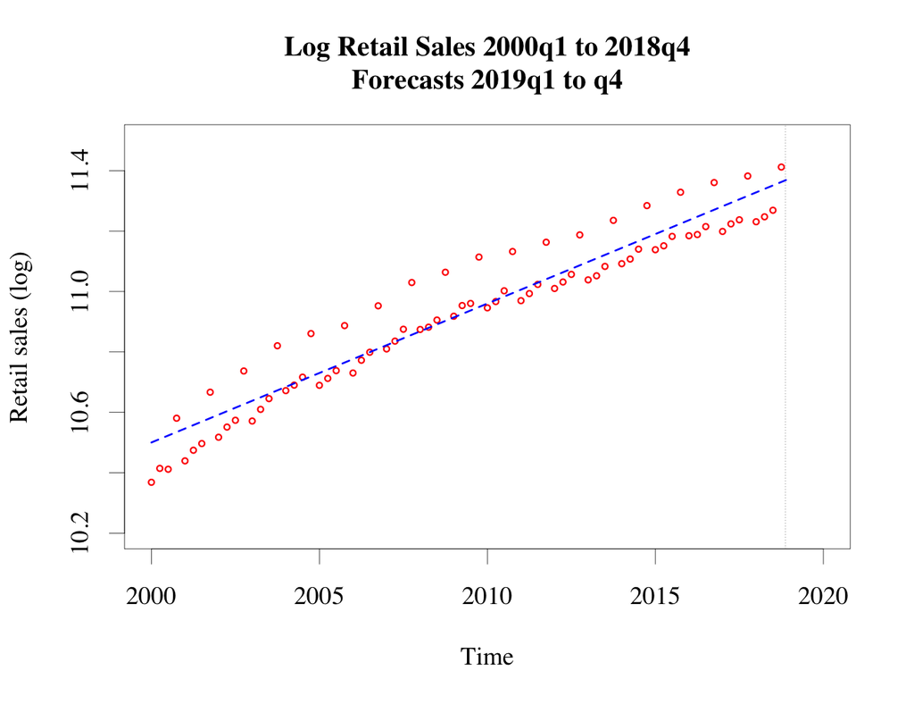

## ${\color{Apricot}{\textsf{predict}}}$ : forecast through 2019

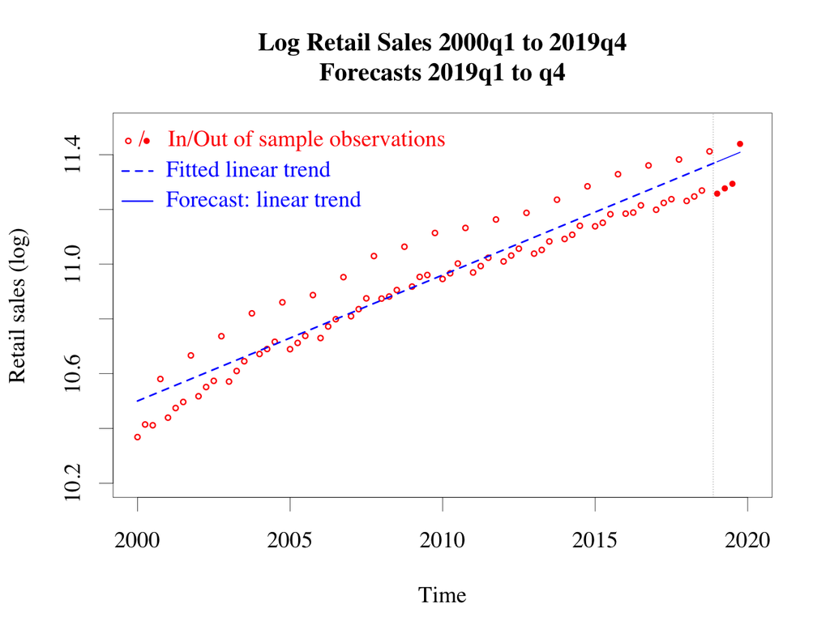

## ${\color{Apricot}{\textsf{predict}}}$ : forecast through 2019

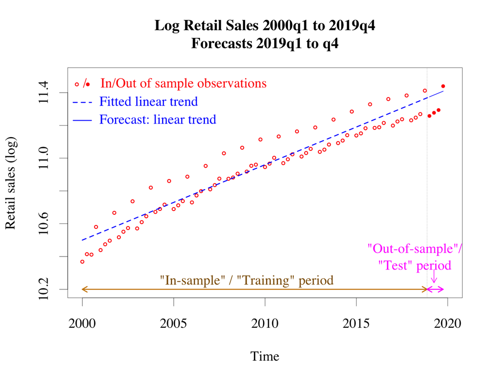

## ${\color{Apricot}{\textsf{predict}}}$ : forecast through 2019

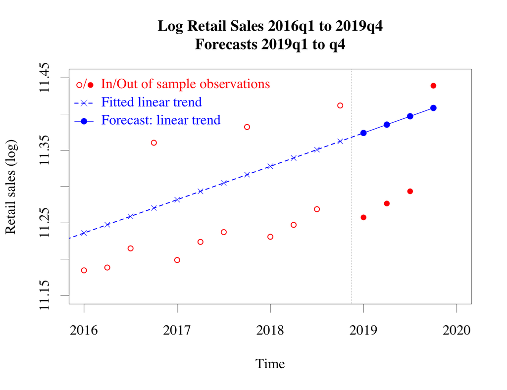

## Residuals and Forecast Errors

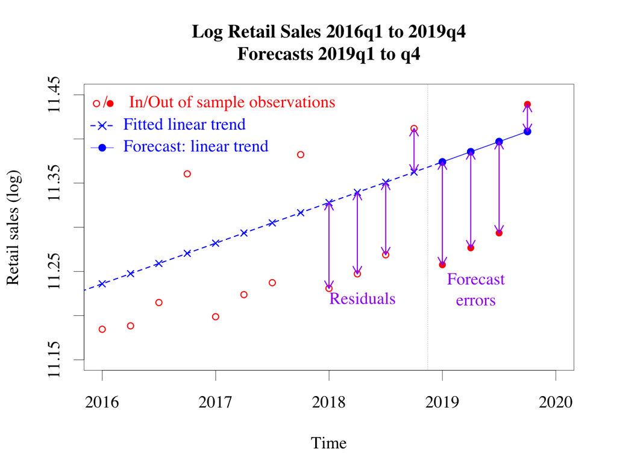

## Residuals and Forecast Errors

$\color{cyan}{\text{In-sample}}:$

$\quad {\color{cyan}{\text{Residual}_t}} = \text{Actual}_t - {\color{cyan}{\text{Fitted}_t}}$

$\color{magenta}{\text{Out-of-sample}}:$

$\quad {\color{magenta}{\text{ForecastError}_t}} = \text{Actual}_t - {\color{magenta}{\text{Forecast}_t}}$

$\text{Patterns in residuals and/or forecast errors}\newline$ $\text{can suggest model mis-specification.}$

## Residuals and Forecast Errors

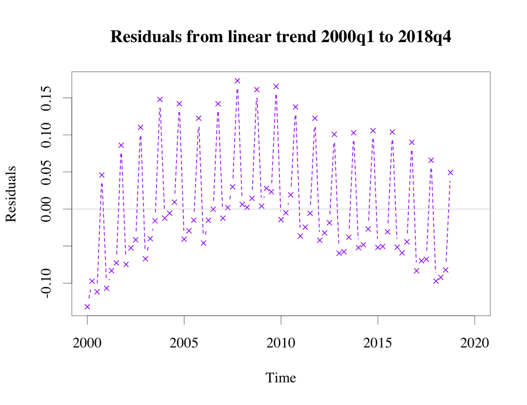

## Residuals and Forecast Errors

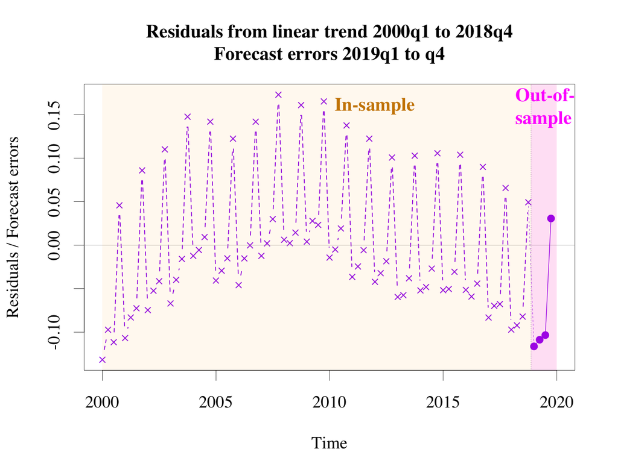

## Residuals and Forecast Errors

$\color{cyan}{\text{In-sample}}:$

$\quad {\color{cyan}{\text{Residual}_t}} = \text{Actual}_t - {\color{cyan}{\text{Fitted}_t}}$

$\color{magenta}{\text{Out-of-sample}}:$

$\quad {\color{magenta}{\text{ForecastError}_t}} = \text{Actual}_t - {\color{magenta}{\text{Forecast}_t}}$

$\text{Residuals and forecast errors show } \textit{seasonality}.$

## The Path Ahead

- Formalise the concept of “forecasting”.
- Develop a range of models for forecasting.
- Methods for model selection, evaluation and interpretation.